```python
import pandas as pd
import pydot

from decision_tree import *
```

# Report 17/06/2019

## Plan

```
 I. Context
 II. Current situation
 III. Methods
      III.1. Random Forest
      III.2. Others
 IV. Results
```

## I. Context

- **Initial goal** : categorize pixel in cloud or not cloud pixels.
- **How**: throw 13 different methods (10 based on difference between the image and non cloud ground - 3 ready to use decision trees).
- **Dataset** : public dataset ([repo](https://gitext.gfz-potsdam.de/EnMAP/sentinel2_manual_classification_clouds)) answering the question if a pixel is a cloud or not.
- **Goal of the report**: build a robust cloud detection model based and our set of methods

## II. Current situation

- **Methods processing**: the main buggs present in our methods has been fixed
  - Not sqare image : all the image haven't the same shape (solved by adding a common area criteria)
  - Duplicated images : some images have been sampled at the same date but prodided at different dates. As result, there are duplicated image with different ids (solved by filtering the sample date and distribution date)
  - Full mask bands : some extra bands are always empty (QA10 - QA20) (solved by ignoring those problematic bands)
- After processing all those images, the methods still fail on some pixels. That lead use to remove :
  - Training set : 3036 pixels from the 200 000 as input (1.5%)
  - Evaluation dataset: 924 pixels from the 60 000 as input (1.5%)

  => The final valid datset in composed by 196964 samples and the evaluation dataset by 59076 pixels.

The dataset looks like this:

```python
# Load module
import pandas as pd
# Load training - evaluation dataset
training = pd.read_excel("Data/results.xlsx", sheet_name="Training")
evaluation = pd.read_excel("Data/results.xlsx", sheet_name="Evaluation")

# Creating feature - output dataset
x_train, y_train = split_feature_output(training, show_time= False)
x_test, y_test = split_feature_output(evaluation, show_time=False)

# Create whole dataset
data = training.append(evaluation)
data.head()
```

|  | cloud | id_GEE | index | latitude | longitude | percentile1 | percentile2 | percentile3 | percentile4 | percentile5 | persistence1 | persistence2 | persistence3 | persistence4 | persistence5 | tree1 | tree2 | tree3 |
| --- | --- | --- | --- | --- | --- | --- | --- | --- | --- | --- | --- | --- | --- | --- | --- | --- | --- | --- |
| 0 | 1 | COPERNICUS/S2/20151203T105422_20151203T105811_... | 0 | 38.065710 | -0.786016 | 0 | 0 | 0 | 0 | 0 | 0 | 1 | 0 | 1 | 0 | 0 | 0 | 0 |
| 1 | 0 | COPERNICUS/S2/20151203T105422_20151203T105811_... | 1 | 38.349942 | -1.563068 | 0 | 0 | 0 | 0 | 0 | 0 | 1 | 0 | 1 | 0 | 0 | 0 | 0 |
| 2 | 0 | COPERNICUS/S2/20151203T105422_20151203T105811_... | 2 | 37.994208 | -1.775253 | 0 | 0 | 0 | 0 | 0 | 0 | 1 | 0 | 1 | 0 | 0 | 0 | 0 |
| 3 | 0 | COPERNICUS/S2/20151203T105422_20151203T105811_... | 3 | 38.725824 | -0.892539 | 0 | 0 | 0 | 0 | 0 | 0 | 1 | 0 | 1 | 0 | 0 | 0 | 0 |
| 4 | 0 | COPERNICUS/S2/20151203T105422_20151203T105811_... | 4 | 38.025237 | -0.878142 | 0 | 0 | 0 | 0 | 0 | 0 | 1 | 0 | 1 | 0 | 0 | 0 | 0 |

Let see the repartition of the differents columns:

[figure not shown]

```python
# Keep usefull columns
data = data[["cloud"] + list(data.columns[5:])]

plt.rcParams["figure.figsize"] = (20,10)

def get_sum(col):
    return [sum(col == 0), sum(col == 1)]

res = data.apply(get_sum, axis=0).to_frame()

res = pd.DataFrame(res[0].values.tolist(), columns=[
                   "Cloud", "Not cloud"], index=res.index).stack().to_frame()
res.reset_index(inplace=True)
res = res.set_axis(['Method', 'Cloud ?', 'Count'], axis=1, inplace=False)

sns.barplot(x="Method", y="Count", hue="Cloud ?", data=res).set_title('Distribution of prediction methods')
plt.show()
```

**Correlation**

Note, having a full correlation doesn't mean the methods are perfect.

```python
# Plot size
plt.figure(figsize=(20,10))

data.corr().style.background_gradient(cmap='coolwarm').set_precision(2)
```

|  | cloud | percentile1 | percentile2 | percentile3 | percentile4 | percentile5 | persistence1 | persistence2 | persistence3 | persistence4 | persistence5 | tree1 | tree2 | tree3 |
| --- | --- | --- | --- | --- | --- | --- | --- | --- | --- | --- | --- | --- | --- | --- |
| cloud | 1 | 0.55 | 0.49 | 0.27 | 0.49 | 0.6 | 0.38 | 0.41 | 0.32 | 0.42 | 0.49 | 0.71 | 0.87 | 0.89 |
| percentile1 | 0.55 | 1 | 0.78 | 0.56 | 0.77 | 0.69 | 0.59 | 0.57 | 0.6 | 0.61 | 0.62 | 0.58 | 0.53 | 0.54 |
| percentile2 | 0.49 | 0.78 | 1 | 0.67 | 0.84 | 0.61 | 0.5 | 0.61 | 0.66 | 0.62 | 0.59 | 0.61 | 0.53 | 0.51 |
| percentile3 | 0.27 | 0.56 | 0.67 | 1 | 0.68 | 0.43 | 0.39 | 0.48 | 0.69 | 0.49 | 0.45 | 0.39 | 0.32 | 0.28 |
| percentile4 | 0.49 | 0.77 | 0.84 | 0.68 | 1 | 0.59 | 0.51 | 0.58 | 0.68 | 0.65 | 0.63 | 0.58 | 0.53 | 0.5 |
| percentile5 | 0.6 | 0.69 | 0.61 | 0.43 | 0.59 | 1 | 0.56 | 0.51 | 0.47 | 0.49 | 0.63 | 0.52 | 0.55 | 0.59 |
| persistence1 | 0.38 | 0.59 | 0.5 | 0.39 | 0.51 | 0.56 | 1 | 0.61 | 0.45 | 0.54 | 0.49 | 0.38 | 0.36 | 0.36 |
| persistence2 | 0.41 | 0.57 | 0.61 | 0.48 | 0.58 | 0.51 | 0.61 | 1 | 0.51 | 0.66 | 0.53 | 0.47 | 0.42 | 0.41 |
| persistence3 | 0.32 | 0.6 | 0.66 | 0.69 | 0.68 | 0.47 | 0.45 | 0.51 | 1 | 0.53 | 0.47 | 0.45 | 0.35 | 0.33 |
| persistence4 | 0.42 | 0.61 | 0.62 | 0.49 | 0.65 | 0.49 | 0.54 | 0.66 | 0.53 | 1 | 0.52 | 0.44 | 0.44 | 0.43 |
| persistence5 | 0.49 | 0.62 | 0.59 | 0.45 | 0.63 | 0.63 | 0.49 | 0.53 | 0.47 | 0.52 | 1 | 0.5 | 0.5 | 0.51 |
| tree1 | 0.71 | 0.58 | 0.61 | 0.39 | 0.58 | 0.52 | 0.38 | 0.47 | 0.45 | 0.44 | 0.5 | 1 | 0.73 | 0.76 |
| tree2 | 0.87 | 0.53 | 0.53 | 0.32 | 0.53 | 0.55 | 0.36 | 0.42 | 0.35 | 0.44 | 0.5 | 0.73 | 1 | 0.89 |
| tree3 | 0.89 | 0.54 | 0.51 | 0.28 | 0.5 | 0.59 | 0.36 | 0.41 | 0.33 | 0.43 | 0.51 | 0.76 | 0.89 | 1 |

# III. Methods

## III.1. Random Forest

The following figure has 2 plots:

- Plot 1: accuracy over the number of estimators
- Plot 2: time processing over the number of estimators

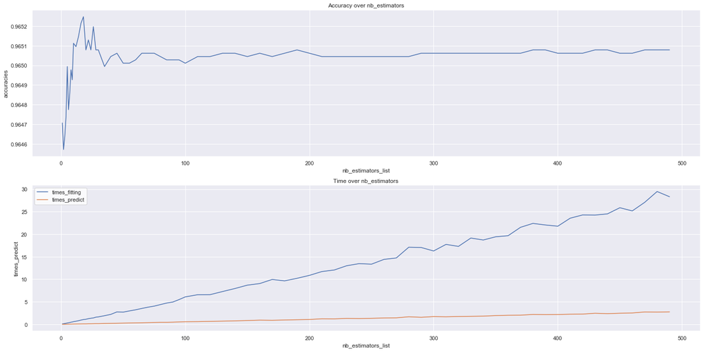

```python
res_rand_forest = compute_accuracy_over_nb_estimators(x_train, x_test, y_train, y_test, show_plot=True, progress_bar=False)
```

Strangely enough, the best accuracy is for a small number of estinator:

```python
print("\n20 best accuracies (sorted):\n", res_rand_forest.sort_values(by="accuracies", ascending=False).head(20))
```

```
20 best accuracies (sorted):
     nb_estimators_list  accuracies  times_fitting  times_predict
13                  18    0.965248       1.063439       0.102939
12                  16    0.965214       0.947580       0.089952
17                  26    0.965197       1.422232       0.144922
11                  14    0.965147       0.806115       0.081955
15                  22    0.965130       1.259618       0.129929
9                   10    0.965113       0.595675       0.059968
10                  12    0.965096       0.691997       0.070961
72                 490    0.965079      28.311630       2.766840
14                  20    0.965079       1.127290       0.100617
42                 190    0.965079      10.212790       1.022714
61                 380    0.965079      22.393324       2.197186
62                 390    0.965079      22.045257       2.162172
19                  30    0.965079       1.653106       0.154226
16                  24    0.965079       1.354518       0.132928
18                  28    0.965079       1.589556       0.157288
67                 440    0.965079      24.506882       2.369545
71                 480    0.965079      29.467413       2.723449
70                 470    0.965079      27.064167       2.747536
66                 430    0.965079      24.237706       2.460081
65                 420    0.965062      24.269393       2.277054
```

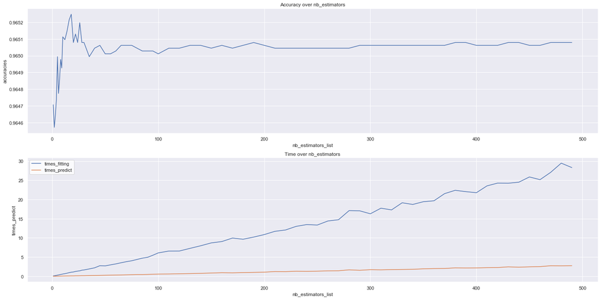

```python
plot_accuracy_over_nb_estimatros(res_rand_forest)
```

### Overfitting !?

If we keep the best tree (18 estimators): the depth of the trees in the random forest model are the following:

```python
# Create result dataframe
res_accuracy = pd.DataFrame({"Methods": data.columns[5:],
                        "Accuracy": [accuracy_score(data.cloud, data[col]) for col in data.columns[5:]]})

# Create Decision Tree classifer object
model_rf = RandomForestClassifier(n_estimators=18, random_state=0)
# Fit model
model_rf.fit(x_train, y_train)
# Predict the response for test dataset
y_pred = model_rf.predict(x_test)

accuracy = accuracy_score(y_test, y_pred)
add_row(res_accuracy, ["randomForest", accuracy])

# Save the tree as a png image
export_graphviz(model_rf.estimators_[0], out_file='tree_rf.dot',
                feature_names=list(training.columns[5:]),
                class_names=["Not Cloudy", "Cloudy"],
                rounded=True, precision=1)
(graph, ) = pydot.graph_from_dot_file('tree_rf.dot')
graph.write_png('tree_rf.png')

print("Trees depth: ", [estimator.tree_.max_depth for estimator in model_rf.estimators_])
```

```
Trees depth:  [13, 13, 13, 13, 13, 13, 13, 13, 13, 13, 13, 13, 13, 13, 13, 13, 13, 13]
```

The first tree of the decision tree looks like this:

[figure not shown]

## III.Others methods

I have also try to build two others models: **a logistic regression model** and a **decision tree** model.

### III.1. Decision tree

The decision tree is also very deep rising the same overfitting issue:

```python
# Create Decision Tree classifer object
tree = DecisionTreeClassifier()
# Train Decision Tree Classifer
tree = tree.fit(x_train, y_train)
# Predict the response for test dataset
y_pred = tree.predict(x_test)

accuracy = accuracy_score(y_test, y_pred)
add_row(res_accuracy, ["decisionTree", accuracy])

# Save the tree as a png image
export_graphviz(model_rf.estimators_[0], out_file='decision_tree.dot',
                feature_names=list(training.columns[5:]),
                class_names=["Not Cloudy", "Cloudy"],
                rounded=True, precision=1)
(graph, ) = pydot.graph_from_dot_file('decision_tree.dot')
graph.write_png('decision_tree.png')

print("Tree depth: ", tree.tree_.max_depth)
```

```
Tree depth:  13
```

The tree is similar to the ones from the random forest model:

[figure not shown]

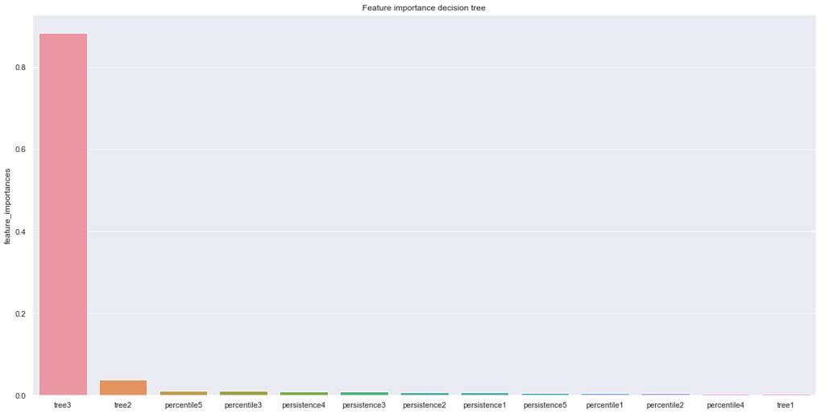

```python
col_names = ['percentile1',
             'percentile2', 'percentile3', 'percentile4', 'percentile5',
             'persistence1', 'persistence2', 'persistence3', 'persistence4',
             'persistence5', 'tree1', 'tree2', 'tree3']
tmp = dict(zip(col_names, tree.feature_importances_))
tmp = {key:[value] for key, value in tmp.items()}
tmp = pd.DataFrame(tmp).T
tmp.columns = ["feature_importances"]
tmp = tmp.sort_values(by="feature_importances", ascending=False)
sns.barplot(x = tmp.index , y="feature_importances", data=tmp).set_title("Feature importance decision tree")
```

### III.2. Logistic regression

```python
from sklearn.linear_model import LogisticRegression
# Create model
model = LogisticRegression(solver='liblinear')
# Fit model
model.fit(x_train, y_train)
# Predict the response for test dataset (proba output)
y_pred = model.predict(x_test)
# Categorize the output
y_pred = np.where(y_pred > 0.5, 1, 0)

accuracy = accuracy_score(y_test, y_pred)
add_row(res_accuracy, ["logisticRegression", accuracy])
a = 1
```

# IV. Results

The results of the different models (accuracy):

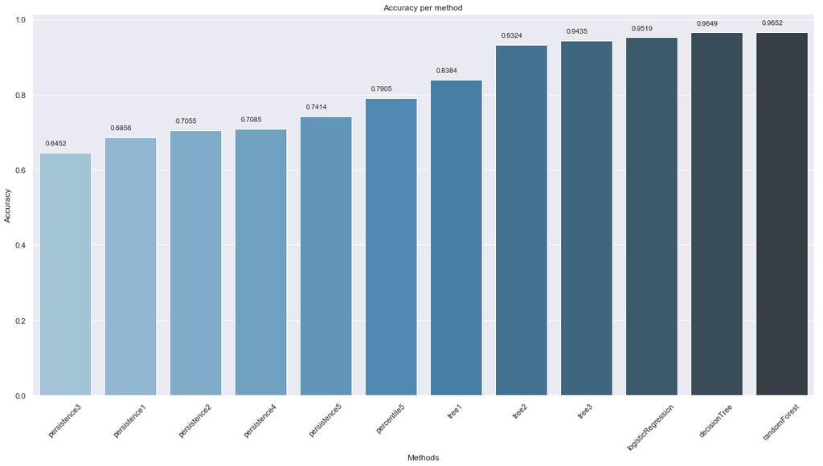

```python
plot_accuracy_over_methods(res_accuracy)
```